# Regresiones lineales con R

Julian Camilo Cruz Sanchez

25/5/2021

[figure not shown]

## Descripción de la base de datos

La base de datos utilizada en este documento contiene información sobre un **negocio** que invierte cierta cantidad de dinero en **publicidad** y obtiene ciertas **ventas**, agrupando estos datos de forma mensual. Tal como se menciona anteriormente, las variables, ambas **cuantitativas** y relacionadas para una correcta creación de un modelo de regresión lineal, son las siguientes:

- **InversionEnPublicidad:** Denotado en la cantidad de dinero en COP
- **VentasObtenidas:** Denotado en la cantidad numerica de unidades

Al realizar un modelo de regresión lineal se podran **predecir valores proximos** de ventas que se obtendrán al invertir dinero en publicidad de una forma mucho mas exacta y tomando en cuenta el **comportamiento y relación directamente proprocional** que tienen las dos variables.

## Creando un modelo de regresión lineal

Inicialmente se exportan los datos y se hace una **limpieza superficial**, en este caso unicamente un cambio de titulos para las variables, debido a la simpleza de la base de datos:

```r
setwd("C:/Users/Retray/Desktop/R/DataBasesAnalysis/LinearRegression")
library(readxl)
sales = read_excel(file.choose())
names(sales) = c("InversionEnPublicidad", "VentasObtenidas")
```

A continuación es importante **verificar la correlación entre las dos variables**, asegurando que al realizar un modelo de regresión simple se tengan datos validos. Se espera que al obtener este coeficiente de relación de Pearson, se encuentre en un **rango positivo y aceptable** ( mayor a 0 y lo más cercano a 1 ):

```r
cor(sales$InversionEnPublicidad, sales$VentasObtenidas)
```

```
## [1] 0.5784877
```

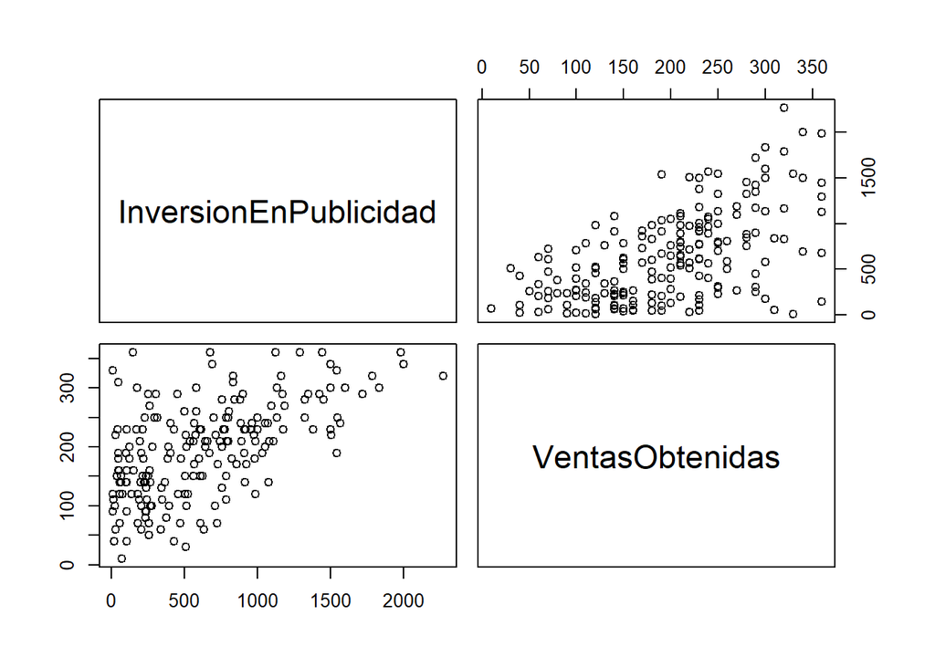

```r
pairs(sales)
```

Dadas estas dos variables correlacionadas, se pueden graficar los valores uno a uno para ver la **dispersion generada por datos no generados mediante una función, sino mediante mediciones con muchos factores de varianza**:

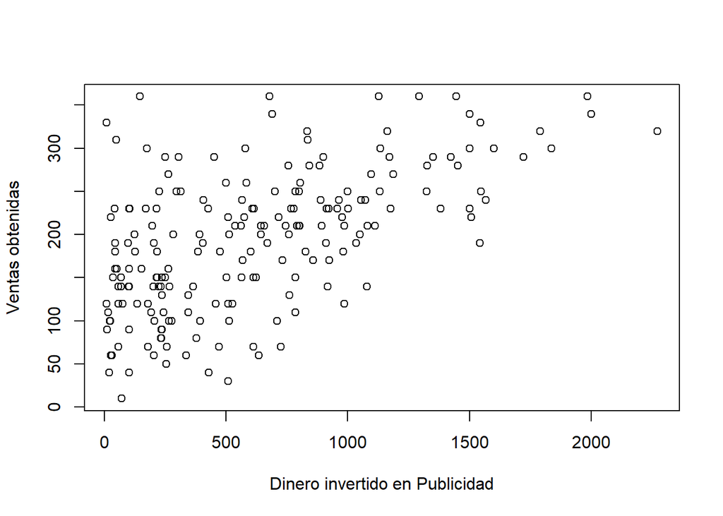

```r
plot(sales$InversionEnPublicidad, sales$VentasObtenidas, xlab="Dinero invertido en Publicidad", ylab = "Ventas obtenidas")
```

Ahora se creará un modelo lineal que tome en cuenta todos los valores para crear una **linea de tendencia general:**

```r
regressionVariable = sales$InversionEnPublicidad
linearRegression <- lm(as.matrix(sales) ~ sales$InversionEnPublicidad, data = sales)
summary(linearRegression)
```

```
## Response InversionEnPublicidad :
##
## Call:
## lm(formula = InversionEnPublicidad ~ sales$InversionEnPublicidad,
##     data = sales)
##
## Residuals:
##        Min         1Q     Median         3Q        Max
## -2.398e-12 -2.490e-15  1.198e-14  2.463e-14  1.760e-13
##
## Coefficients:
##                              Estimate Std. Error   t value Pr(>|t|)
## (Intercept)                 2.572e-13  1.998e-14 1.288e+01   <2e-16 ***
## sales$InversionEnPublicidad 1.000e+00  2.554e-17 3.916e+16   <2e-16 ***
## ---
## Signif. codes:  0 '***' 0.001 '**' 0.01 '*' 0.05 '.' 0.1 ' ' 1
##
## Residual standard error: 1.749e-13 on 198 degrees of freedom
## Multiple R-squared:      1,  Adjusted R-squared:      1
## F-statistic: 1.534e+33 on 1 and 198 DF,  p-value: < 2.2e-16
##
##
## Response VentasObtenidas :
##
## Call:
## lm(formula = VentasObtenidas ~ sales$InversionEnPublicidad, data = sales)
##
## Residuals:
##      Min       1Q   Median       3Q      Max
## -152.949  -43.796   -0.393   37.040  211.866
##
## Coefficients:
##                              Estimate Std. Error t value Pr(>|t|)
## (Intercept)                 1.341e+02  7.537e+00  17.799   <2e-16 ***
## sales$InversionEnPublicidad 9.612e-02  9.632e-03   9.979   <2e-16 ***
## ---
## Signif. codes:  0 '***' 0.001 '**' 0.01 '*' 0.05 '.' 0.1 ' ' 1
##
## Residual standard error: 65.99 on 198 degrees of freedom
## Multiple R-squared:  0.3346, Adjusted R-squared:  0.3313
## F-statistic: 99.59 on 1 and 198 DF,  p-value: < 2.2e-16
```

## Datos importantes de la regresión lineal

**Intervalo de confianza del 95%:**

```r
confint(linearRegression)
```

```
##                                                          2.5 %       97.5 %
## InversionEnPublicidad:(Intercept)                 2.178434e-13 2.966445e-13
## InversionEnPublicidad:sales$InversionEnPublicidad 1.000000e+00 1.000000e+00
## VentasObtenidas:(Intercept)                       1.192777e+02 1.490022e+02
## VentasObtenidas:sales$InversionEnPublicidad       7.712929e-02 1.151197e-01
```

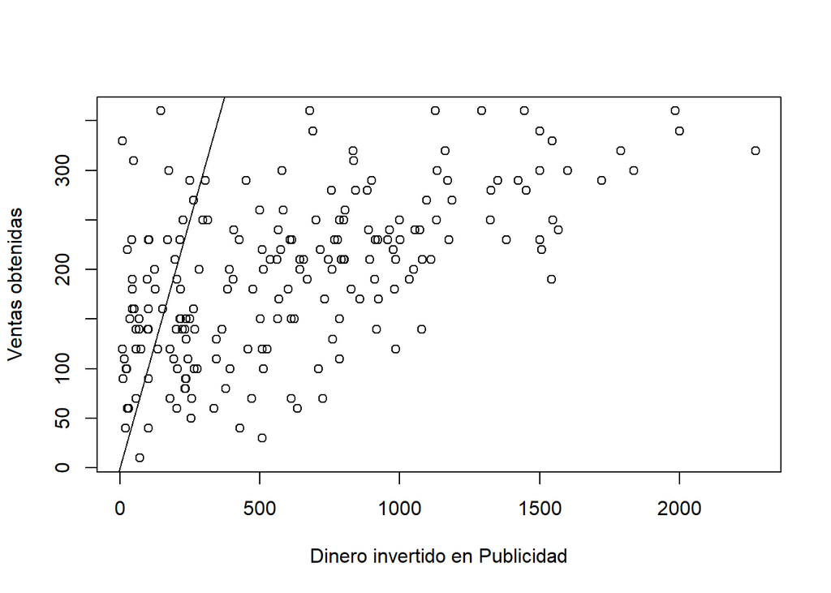

```r
plot(sales$InversionEnPublicidad, sales$VentasObtenidas, xlab="Dinero invertido en Publicidad", ylab = "Ventas obtenidas")
abline(linearRegression)
```

**Gráfica de normalidad:**

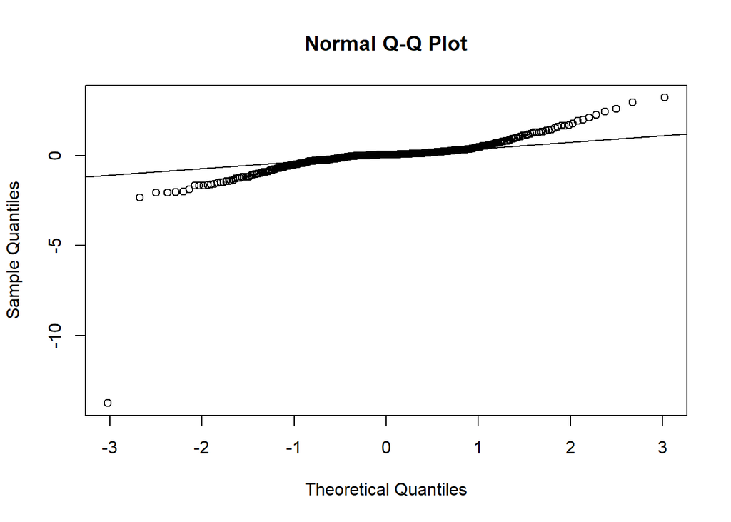

```r
residue = rstandard(linearRegression)
qqnorm(residue)
qqline(residue)
```